# 대한민국 제21대 국회의원 선거

출마자 신상정보: 데이터

[Tidyverse Korea](https://www.facebook.com/groups/tidyverse/)

2020-03-29

# 1 선거통계 - 후보자 명부

[후보자정보](http://info.nec.go.kr/main/showDocument.xhtml?electionId=0020200415&topMenuId=CP&secondMenuId=CPRI03)를 가져와서 다양한 비교분석 작업을 수행한다.

## 1.1 성남 분당구 을

“성남시 분당구 을”을 선구구를 대상으로 후보자 정보를 추출한다.

```r
library(tidyverse)
library(rvest)
library(httr)

Sys.setlocale("LC_ALL", "C")
```

```
[1] "C"
```

```r
candidate_url <- "http://info.nec.go.kr/electioninfo/electionInfo_report.xhtml?electionId=0020200415&requestURI=%2FWEB-INF%2Fjsp%2Felectioninfo%2F0020200415%2Fcp%2Fcpri03.jsp&topMenuId=CP&secondMenuId=CPRI03&menuId=CPRI03&statementId=CPRI03_%232&electionCode=2&cityCode=4100&sggCityCode=2410702&proportionalRepresentationCode=0&townCode=-1&dateCode=0&x=31&y=9"

candidate_html <- read_html(candidate_url)

candidate_dat <- candidate_html %>%
  html_node('table') %>%
  html_table(fill = TRUE)

Sys.setlocale("LC_ALL", "Korean")
```

```
[1] "LC_COLLATE=Korean_Korea.949;LC_CTYPE=Korean_Korea.949;LC_MONETARY=Korean_Korea.949;LC_NUMERIC=C;LC_TIME=Korean_Korea.949"
```

```r
candidate_df <- candidate_dat %>%
  janitor::clean_names() %>%
  slice(2:n()) %>%
  names

candidate_df <- candidate_dat %>%
  janitor::clean_names() %>%
  slice(2:n()) %>%
  set_names(c("선거구명", "사진", "기호", "정당명", "성명", "성별",
              "생년월일_연령", "주소", "직업", "학력", "경력", "재산",
              "병역", "납부액", "체납액", "현체납액",
              "전과", "입후보횟수")) %>%
  separate(생년월일_연령, into=c("생년월일", "연령"), sep="\\(") %>%
  mutate(`연령` = parse_number(`연령`),
         재산 = parse_number(재산),
         납부액 = parse_number(납부액),
         체납액 = parse_number(체납액),
         현체납액 = parse_number(현체납액),
         전과 = str_remove(전과, "건"),
         입후보횟수 = parse_number(입후보횟수)) %>%
  mutate(전과 = ifelse(전과 == "없음", 0, 전과) %>% as.integer) %>%
  mutate(병역 = case_when(str_detect(병역, "마친사람") ~ "병필",
                          str_detect(병역, "아니한") ~ "미필",
                          str_detect(병역, "비대상") ~ "여성"))

candidate_df %>%
  select(정당명, 성명, 성별, 연령, 재산, 직업, 병역) %>%
  DT::datatable()
```

|  | 정당명 | 성명 | 성별 | 연령 | 재산 | 직업 | 병역 |
| --- | --- | --- | --- | --- | --- | --- | --- |
| 1 | 더불어민주당 | 김병욱(金炳旭) | 남 | 55 | 4542697 | 국회의원 | 미필 |
| 2 | 미래통합당 | 김민수(金玟秀) | 남 | 41 | 3232294 | 정당인 | 병필 |
| 3 | 정의당 | 양호영(楊鎬榮) | 남 | 47 | 56455 | 정당인 | 병필 |
| 4 | 우리공화당 | 채지민(蔡志旼) | 여 | 30 | 210174 | 정당인 | 여성 |
| 5 | 민중당 | 김미라(金美羅) | 여 | 46 | 61779 | 정당인 | 여성 |
| 6 | 국가혁명배당금당 | 송의준(宋義晙) | 남 | 69 | -2254015 | 정당인 | 병필 |
| 7 | 무소속 | 이나영(李娜榮) | 여 | 34 | -64356 | 무직 | 여성 |

## 1.2 함수

“성남시 분당구 을”을 선구구를 대상으로 후보자 정보를 추출한 후 테스트를 통해 다음 단계로 넘어가기 위해서 함수를 제작한다. 즉, 특정 지역구정보를 넣게 되면 후보자 정보를 추출하게 되는 것이다. 중앙선거관리위원회, 선거통계시스템, 후보자 명부 시스템 분석결과 `cityCode`, `sggCityCode` 두개가 중요한 매개변수가 된다. 예를 들어, 서울특별시 종로구의 경우 `cityCode`, `sggCityCode`가 각각 다음과 같다.

- `cityCode`: 1100
- `sggCityCode`: 2110101

```r
get_candidate_info <- function(cityCode, sgg_CityCode) {

  Sys.setlocale("LC_ALL", "C")

  candidate_url <- glue::glue("http://info.nec.go.kr/electioninfo/electionInfo_report.xhtml?electionId=0020200415&requestURI=%2FWEB-INF%2Fjsp%2Felectioninfo%2F0020200415%2Fcp%2Fcpri03.jsp&topMenuId=CP&secondMenuId=CPRI03&menuId=CPRI03&statementId=CPRI03_%232&electionCode=2&cityCode={cityCode}&sggCityCode={sgg_CityCode}&proportionalRepresentationCode=0&townCode=-1&dateCode=0&x=31&y=9")

  candidate_html <- read_html(candidate_url)

  candidate_dat <- candidate_html %>%
    html_node('table') %>%
    html_table(fill = TRUE)

  Sys.setlocale("LC_ALL", "Korean")

  candidate_df <- candidate_dat %>%
    janitor::clean_names() %>%
    slice(2:n()) %>%
    names

  candidate_df <- candidate_dat %>%
    janitor::clean_names() %>%
    slice(2:n()) %>%
    set_names(c("선거구명", "사진", "기호", "정당명", "성명", "성별",
                "생년월일_연령", "주소", "직업", "학력", "경력", "재산",
                "병역", "납부액", "체납액", "현체납액",
                "전과", "입후보횟수")) %>%
    separate(생년월일_연령, into=c("생년월일", "연령"), sep="\\(") %>%
    mutate(`연령` = parse_number(`연령`),
           재산 = parse_number(재산),
           납부액 = parse_number(납부액),
           체납액 = parse_number(체납액),
           현체납액 = parse_number(현체납액),
           전과 = str_remove(전과, "건"),
           입후보횟수 = parse_number(입후보횟수)) %>%
    mutate(전과 = ifelse(전과 == "없음", 0, 전과) %>% as.integer) %>%
    mutate(병역 = case_when(str_detect(병역, "마친사람") ~ "병필",
                            str_detect(병역, "아니한") ~ "미필",
                            str_detect(병역, "비대상") ~ "여성"))

  return(candidate_df)
}

get_candidate_info(1100, 2110101) %>%
  tbl_df
```

```
# A tibble: 12 x 19
   선거구명 사진  기호  정당명 성명  성별  생년월일  연령 주소  직업  학력
   <chr>    <chr> <chr> <chr>  <chr> <chr> <chr>    <dbl> <chr> <chr> <chr>
 1 종로구   ""    1     더불어민주~ 이낙연(~ 남    1952.12~    67 서울특별~ 정당인~ 서울대학~
 2 종로구   ""    2     미래통합당~ 황교안(~ 남    1957.04~    63 서울특별~ 미래통합~ 성균관대~
 3 종로구   ""    7     우리공화당~ 한민호(~ 남    1962.01~    58 서울특별~ 정당인~ 성균관대~
 4 종로구   ""    8     민중당 오인환(~ 남    1973.01~    47 서울특별~ 정당인~ 경희대학~
 5 종로구   ""    9     가자!평화~ 이정희(~ 여    1964.10~    55 서울특별~ 가자평화~ 고려대학~
 6 종로구   ""    10    공화당 신동욱(~ 남    1968.01~    52 서울특별~ 정당인~ 서울벤처~
 7 종로구   ""    11    국가혁명배~ 박준영(~ 남    1937.02~    83 서울특별~ 국제정치~ 서울대학~
 8 종로구   ""    12    국민새정당~ 백병찬(~ 남    1956.04~    64 서울특별~ 국민새정~ 미기재~
 9 종로구   ""    13    기독자유통~ 양세화(~ 여    1982.02~    38 경기도 ~ 정당인~ 강원관광~
10 종로구   ""    14    민중민주당~ 박소현(~ 여    1991.02~    29 인천광역~ 정당인~ 고려대학~
11 종로구   ""    15    한나라당~ 김형석(~ 남    1966.04~    53 서울특별~ 방송통신~ 한국방송~
12 종로구   ""    16    무소속 김용덕(~ 남    1951.01~    69 전라북도~ 농업  군장대학~
# ... with 8 more variables: 경력 <chr>, 재산 <dbl>, 병역 <chr>, 납부액 <dbl>,
#   체납액 <dbl>, 현체납액 <dbl>, 전과 <int>, 입후보횟수 <dbl>
```

```r
# 강원
# get_candidate_info(4200, 2420101) %>%
#   tbl_df
```

## 1.3 `cityCode`, `sggCityCode`

`cityCode`, `sggCityCode` 코드를 찾아야 나머지 분석작업을 자동화시킬 수 있다.

```r
## 시도코드
cityCode <- tribble(~"cityCode", ~"cityName",
                    "1100", "서울특별시",
                    "2600", "부산광역시",
                    "2700", "대구광역시",
                    "2800", "인천광역시",
                    "2900", "광주광역시",
                    "3000", "대전광역시",
                    "3100", "울산광역시",
                    "5100", "세종특별자치시",
                    "4100", "경기도",
                    "4200", "강원도",
                    "4300", "충청북도",
                    "4400", "충청남도",
                    "4500", "전라북도",
                    "4600", "전라남도",
                    "4700", "경상북도",
                    "4800", "경상남도",
                    "4900", "제주특별자치도")

## 시군구코드
### 서울특별시
sgg_서울 <- tribble(~"sggCityCode", ~"sggCityName",
                   "2110101", "종로구",
                   "2110402", "중구성동구갑",
                   "2110201", "중구성동구을",
                   "2110301", "용산구",
                   "2110501", "광진구갑",
                   "2110502", "광진구을",
                   "2110601", "동대문구갑",
                   "2110602", "동대문구을",
                   "2110701", "중랑구갑",
                   "2110702", "중랑구을",
                   "2110801", "성북구갑",
                   "2110802", "성북구을",
                   "2110901", "강북구갑",
                   "2110902", "강북구을",
                   "2111001", "도봉구갑",
                   "2111002", "도봉구을",
                   "2111101", "노원구갑",
                   "2111102", "노원구을",
                   "2111103", "노원구병",
                   "2111201", "은평구갑",
                   "2111202", "은평구을",
                   "2111301", "서대문구갑",
                   "2111302", "서대문구을",
                   "2111401", "마포구갑",
                   "2111402", "마포구을",
                   "2111501", "양천구갑",
                   "2111502", "양천구을",
                   "2111601", "강서구갑",
                   "2111602", "강서구을",
                   "2111603", "강서구병",
                   "2111701", "구로구갑",
                   "2111702", "구로구을",
                   "2111801", "금천구",
                   "2111901", "영등포구갑",
                   "2111902", "영등포구을",
                   "2112001", "동작구갑",
                   "2112002", "동작구을",
                   "2112101", "관악구갑",
                   "2112102", "관악구을",
                   "2112201", "서초구갑",
                   "2112202", "서초구을",
                   "2112301", "강남구갑",
                   "2112302", "강남구을",
                   "2112303", "강남구병",
                   "2112401", "송파구갑",
                   "2112402", "송파구을",
                   "2112403", "송파구병",
                   "2112501", "강동구갑",
                   "2112502", "강동구을")

### 부산광역시
sgg_부산 <- tribble(~"sggCityCode", ~"sggCityName",
                   "2260401", "중구영도구",
                   "2260201", "서구동구",
                   "2260501", "부산진구갑",
                   "2260502", "부산진구을",
                   "2260601", "동래구",
                   "2260701", "남구갑",
                   "2260702", "남구을",
                   "2260801", "북구강서구갑",
                   "2261301", "북구강서구을",
                   "2260902", "해운대구갑",
                   "2260903", "해운대구을",
                   "2261101", "사하구갑",
                   "2261102", "사하구을",
                   "2261201", "금정구",
                   "2261401", "연제구",
                   "2261501", "수영구",
                   "2261601", "사상구",
                   "2261002", "기장군")

### 대구광역시
sgg_대구 <- tribble(~"sggCityCode", ~"sggCityName",
                  "2270101", "중구남구",
                  "2270201", "동구갑",
                  "2270202", "동구을",
                  "2270301", "서구",
                  "2270501", "북구갑",
                  "2270502", "북구을",
                  "2270601", "수성구갑",
                  "2270602", "수성구을",
                  "2270701", "달서구갑",
                  "2270702", "달서구을",
                  "2270703", "달서구병",
                  "2270801", "달성군")

### 인천광역시
sgg_인천 <- tribble(~"sggCityCode", ~"sggCityName",
                  "2280101", "중구강화군옹진군",
                  "2280301", "동구미추홀구갑",
                  "2280302", "동구미추홀구을",
                  "2280402", "연수구갑",
                  "2280403", "연수구을",
                  "2280501", "남동구갑",
                  "2280502", "남동구을",
                  "2280601", "부평구갑",
                  "2280602", "부평구을",
                  "2280701", "계양구갑",
                  "2280702", "계양구을",
                  "2280802", "서구갑",
                  "2280803", "서구을")

### 광주광역시
sgg_광주 <- tribble(~"sggCityCode", ~"sggCityName",
                  "2290302", "동구남구갑",
                  "2290101", "동구남구을",
                  "2290201", "서구갑",
                  "2290202", "서구을",
                  "2290401", "북구갑",
                  "2290402", "북구을",
                  "2290501", "광산구갑",
                  "2290502", "광산구을")

### 대전광역시
sgg_대전 <- tribble(~"sggCityCode", ~"sggCityName",
                  "2300101", "동구",
                  "2300201", "중구",
                  "2300301", "서구갑",
                  "2300302", "서구을",
                  "2300402", "유성구갑",
                  "2300403", "유성구을",
                  "2300501", "대덕구")

### 울산광역시
sgg_울산 <- tribble(~"sggCityCode", ~"sggCityName",
                  "2310101", "중구",
                  "2310201", "남구갑",
                  "2310202", "남구을",
                  "2310301", "동구",
                  "2310401", "북구",
                  "2310501", "울주군")

### 세종특별자치시
sgg_세종 <- tribble(~"sggCityCode", ~"sggCityName",
                  "2510101", "세종특별자치시갑",
                  "2510102", "세종특별자치시을")

### 경기도
sgg_경기 <- tribble(~"sggCityCode", ~"sggCityName",
                  "2410101", "수원시갑",
                  "2410201", "수원시을",
                  "2410301", "수원시병",
                  "2410401", "수원시정",
                  "2410202", "수원시무",
                  "2410501", "성남시수정구",
                  "2410601", "성남시중원구",
                  "2410701", "성남시분당구갑",
                  "2410702", "성남시분당구을",
                  "2410801", "의정부시갑",
                  "2410802", "의정부시을",
                  "2410901", "안양시만안구",
                  "2411001", "안양시동안구갑",
                  "2411002", "안양시동안구을",
                  "2411101", "부천시갑",
                  "2411102", "부천시을",
                  "2411201", "부천시병",
                  "2411301", "부천시정",
                  "2411401", "광명시갑",
                  "2411402", "광명시을",
                  "2411501", "평택시갑",
                  "2411502", "평택시을",
                  "2411701", "동두천시연천군",
                  "2411801", "안산시상록구갑",
                  "2411802", "안산시상록구을",
                  "2411901", "안산시단원구갑",
                  "2411902", "안산시단원구을",
                  "2412001", "고양시갑",
                  "2412002", "고양시을",
                  "2412101", "고양시병",
                  "2412201", "고양시정",
                  "2412301", "의왕시과천시",
                  "2412501", "구리시",
                  "2412601", "남양주시갑",
                  "2412602", "남양주시을",
                  "2412603", "남양주시병",
                  "2412701", "오산시",
                  "2412901", "시흥시갑",
                  "2412902", "시흥시을",
                  "2413002", "군포시",
                  "2413101", "하남시",
                  "2413501", "용인시갑",
                  "2413701", "용인시을",
                  "2413602", "용인시병",
                  "2413702", "용인시정",
                  "2413202", "파주시갑",
                  "2413203", "파주시을",
                  "2413401", "이천시",
                  "2413801", "안성시",
                  "2413902", "김포시갑",
                  "2413903", "김포시을",
                  "2412801", "화성시갑",
                  "2412802", "화성시을",
                  "2412803", "화성시병",
                  "2414002", "광주시갑",
                  "2414003", "광주시을",
                  "2411602", "양주시",
                  "2414102", "포천시가평군",
                  "2413301", "여주시양평군")
```

```r
### 강원도
sgg_강원 <- tribble(~"sggCityCode", ~"sggCityName",
                  "2420101", "춘천시철원군화천군양구군갑",
                  "2420102", "춘천시철원군화천군양구군을",
                  "2420202", "원주시갑",
                  "2420203", "원주시을",
                  "2420301", "강릉시",
                  "2420401", "동해시태백시삼척시정선군",
                  "2420801", "속초시인제군고성군양양군",
                  "2421402", "홍천군횡성군영월군평창군")

### 충청북도
sgg_충북 <- tribble(~"sggCityCode", ~"sggCityName",
                  "2430101", "청주시상당구",
                  "2430201", "청주시서원구",
                  "2430202", "청주시흥덕구",
                  "2430601", "청주시청원구",
                  "2430301", "충주시",
                  "2430401", "제천시단양군",
                  "2430701", "보은군옥천군영동군괴산군",
                  "2431002", "증평군진천군음성군")

### 충청남도
sgg_충남 <- tribble(~"sggCityCode", ~"sggCityName",
                  "2440101", "천안시갑",
                  "2440102", "천안시을",
                  "2440103", "천안시병",
                  "2440202", "공주시부여군청양군",
                  "2440301", "보령시서천군",
                  "2440402", "아산시갑",
                  "2440403", "아산시을",
                  "2440501", "서산시태안군",
                  "2440901", "논산시계룡시금산군",
                  "2441601", "당진시",
                  "2441301", "홍성군예산군")

### 전라북도
sgg_전북 <- tribble(~"sggCityCode", ~"sggCityName",
                  "2450101", "전주시갑",
                  "2450102", "전주시을",
                  "2450201", "전주시병",
                  "2450301", "군산시",
                  "2450501", "익산시갑",
                  "2450502", "익산시을",
                  "2450701", "정읍시고창군",
                  "2450801", "남원시임실군순창군",
                  "2450902", "김제시부안군",
                  "2451001", "완주군진안군무주군장수군")

### 전라남도
sgg_전남 <- tribble(~"sggCityCode", ~"sggCityName",
                  "2460101", "목포시",
                  "2460201", "여수시갑",
                  "2460202", "여수시을",
                  "2460403", "순천시광양시곡성군구례군갑",
                  "2460702", "순천시광양시곡성군구례군을",
                  "2460601", "나주시화순군",
                  "2462202", "담양군함평군영광군장성군",
                  "2461201", "고흥군보성군장흥군강진군",
                  "2461801", "해남군완도군진도군",
                  "2462101", "영암군무안군신안군")

### 경상북도
sgg_경북 <- tribble(~"sggCityCode", ~"sggCityName",
                  "2470101", "포항시북구",
                  "2470201", "포항시남구울릉군",
                  "2470401", "경주시",
                  "2470501", "김천시",
                  "2470601", "안동시예천군",
                  "2470701", "구미시갑",
                  "2470702", "구미시을",
                  "2470802", "영주시영양군봉화군울진군",
                  "2470901", "영천시청도군",
                  "2471002", "상주시문경시",
                  "2471302", "경산시",
                  "2471902", "군위군의성군청송군영덕군",
                  "2471701", "고령군성주군칠곡군")

### 경상남도
sgg_경남 <- tribble(~"sggCityCode", ~"sggCityName",
                  "2480101", "창원시의창구",
                  "2480102", "창원시성산구",
                  "2480201", "창원시마산합포구",
                  "2480202", "창원시마산회원구",
                  "2480401", "창원시진해구",
                  "2480301", "진주시갑",
                  "2480302", "진주시을",
                  "2480501", "통영시고성군",
                  "2480702", "사천시남해군하동군",
                  "2480801", "김해시갑",
                  "2480802", "김해시을",
                  "2480901", "밀양시의령군함안군창녕군",
                  "2481001", "거제시",
                  "2481402", "양산시갑",
                  "2481403", "양산시을",
                  "2481901", "산청군함양군거창군합천군")

### 제주
sgg_제주 <- tribble(~"sggCityCode", ~"sggCityName",
                  "2490101", "제주시갑",
                  "2490102", "제주시을",
                  "2490201", "서귀포시")

# 결합 ----------------------
sgg_강원 <- sgg_강원 %>%
  mutate(cityCode = "4200")

sgg_경기 <- sgg_경기 %>%
  mutate(cityCode = "4100")

sgg_경남 <- sgg_경남 %>%
  mutate(cityCode = "4800")

sgg_경북 <- sgg_경북 %>%
  mutate(cityCode = "4700")

sgg_광주 <- sgg_광주 %>%
  mutate(cityCode = "2900")

sgg_대구 <- sgg_대구 %>%
  mutate(cityCode = "2700")

sgg_대전 <- sgg_대전 %>%
  mutate(cityCode = "3000")

sgg_부산 <- sgg_부산 %>%
  mutate(cityCode = "2600")

sgg_서울 <- sgg_서울 %>%
  mutate(cityCode = "1100")

sgg_세종 <- sgg_세종 %>%
  mutate(cityCode = "5100")

sgg_울산 <- sgg_울산 %>%
  mutate(cityCode = "3100")

sgg_인천 <- sgg_인천 %>%
  mutate(cityCode = "2800")

sgg_전남 <- sgg_전남 %>%
  mutate(cityCode = "4600")

sgg_전북 <- sgg_전북 %>%
  mutate(cityCode = "4500")

sgg_제주 <- sgg_제주 %>%
  mutate(cityCode = "4900")

sgg_충남 <- sgg_충남 %>%
  mutate(cityCode = "4400")

sgg_충북 <- sgg_충북 %>%
  mutate(cityCode = "4300")


sggCityCode <- bind_rows(sgg_강원,sgg_경기,sgg_경남,sgg_경북,sgg_광주,sgg_대구,sgg_대전,
                         sgg_부산,sgg_서울,sgg_세종,sgg_울산,sgg_인천,sgg_전남,sgg_전북,
                         sgg_제주,sgg_충남,sgg_충북)

full_code <- inner_join(cityCode, sggCityCode)

full_code
```

```
# A tibble: 253 x 4
   cityCode cityName   sggCityCode sggCityName
   <chr>    <chr>      <chr>       <chr>
 1 1100     서울특별시 2110101     종로구
 2 1100     서울특별시 2110402     중구성동구갑
 3 1100     서울특별시 2110201     중구성동구을
 4 1100     서울특별시 2110301     용산구
 5 1100     서울특별시 2110501     광진구갑
 6 1100     서울특별시 2110502     광진구을
 7 1100     서울특별시 2110601     동대문구갑
 8 1100     서울특별시 2110602     동대문구을
 9 1100     서울특별시 2110701     중랑구갑
10 1100     서울특별시 2110702     중랑구을
# ... with 243 more rows
```

## 1.4 코드+함수 테스트

서울특별시 종로구를 대상으로 `cityCode`로 1100, `sggCityCode`로 2110101을 `get_candidate_info()` 함수에 전달하여 제대로 데이터를 가져오는지 테스트한다.

```r
get_candidate_info(full_code$cityCode[1], full_code$sggCityCode[1]) %>%
  select(정당명, 성명, 성별, 연령, 재산, 직업, 병역) %>%
  DT::datatable()
```

|  | 정당명 | 성명 | 성별 | 연령 | 재산 | 직업 | 병역 |
| --- | --- | --- | --- | --- | --- | --- | --- |
| 1 | 더불어민주당 | 이낙연(李洛淵) | 남 | 67 | 2436814 | 정당인 | 병필 |
| 2 | 미래통합당 | 황교안(黃敎安) | 남 | 63 | 3340706 | 미래통합당 당대표 | 미필 |
| 3 | 우리공화당 | 한민호(韓民鎬) | 남 | 58 | 1100242 | 정당인 | 병필 |
| 4 | 민중당 | 오인환(吳璘煥) | 남 | 47 | 197497 | 정당인 | 병필 |
| 5 | 가자!평화인권당 | 이정희(李貞嬉) | 여 | 55 | -143000 | 가자평화인권당 공동대표 | 여성 |
| 6 | 공화당 | 신동욱(申東旭) | 남 | 52 | 282609 | 정당인 | 병필 |
| 7 | 국가혁명배당금당 | 박준영(朴俊榮) | 남 | 83 | 0 | 국제정치가 | 병필 |
| 8 | 국민새정당 | 백병찬(白秉贊) | 남 | 64 | 500 | 국민새정당 부총재 겸 수석 대변인 | 병필 |
| 9 | 기독자유통일당 | 양세화(梁世和) | 여 | 38 | 49990 | 정당인 | 여성 |
| 10 | 민중민주당 | 박소현(朴炤炫) | 여 | 29 | 259418 | 정당인 | 여성 |

[output cut: 2 more lines]

## 1.5 전체 데이터

이제 마지막 단계로 전체 시도에 대해서 선거구별로 모든 데이터를 가져온다.

```r
# Original map2 function code
# candidate_df <- map2_df(full_code$cityCode, full_code$sggCityCode, get_candidate_info)

# try-catch login included map2 code
safely_get_candidate_info <- safely(get_candidate_info, otherwise = NA_real_)

candidate_list <- map2(full_code$cityCode, full_code$sggCityCode, safely_get_candidate_info)

## DRY RUN CODE !!!
# for(i in 1:nrow(cityCode)) {
#   for(j in 1:nrow(sggCityCode)) {
#      cat("시도:", cityCode$cityCode[i], "\n")
#      cat("시군구:", sggCityCode$sggCityCode[j], "\n")
#   }
#   cat("===========================\n")
# }

# NO TRY-CATCH FOR LOOP
# candidate_list <- list()
# index <- 1
#
# for(i in 1:nrow(cityCode)) {
#   for(j in 1:nrow(sggCityCode)) {
#      cat("시도:", cityCode$cityCode[i], "\n")
#      cat("시군구:", sggCityCode$sggCityCode[j], "\n")
#      candidate_list[index] <- get_candidate_info(i, j)
#      index <- index + 1
#   }
#   cat("===========================\n")
#   Sys.sleep(runif(1, 0, 3))
# }

candidate_list %>%
  write_rds("data/candidate_list.rds")
```

## 1.6 처리결과 정제

전체 시도에 대해서 선거구별로 수집한 데이터를 살펴보고 정제한다.

```r
candidate_list <- read_rds("data/candidate_list.rds")

candidate_df <- map_df(candidate_list, "result")

candidate_df %>%
  filter(정당명 == "더불어민주당") %>%
  mutate(시도명 = str_extract(주소, ".*?(?=\\s)")) %>%
  count(시도명, 선거구명)
```

```
# A tibble: 253 x 3
   시도명 선거구명                       n
   <chr>  <chr>                      <int>
 1 강원도 강릉시                         1
 2 강원도 동해시태백시삼척시정선군       1
 3 강원도 속초시인제군고성군양양군       1
 4 강원도 원주시갑                       1
 5 강원도 원주시을                       1
 6 강원도 춘천시철원군화천군양구군갑     1
 7 강원도 춘천시철원군화천군양구군을     1
 8 강원도 홍천군횡성군영월군평창군       1
 9 경기도 고양시갑                       1
10 경기도 고양시병                       1
# ... with 243 more rows
```

# 2 데이터 품질

## 2.1 시도별 확인

```r
## 크롤링 선거구
### 서울특별시:49
precinct_서울 <- full_code %>%
  filter(cityName == "서울특별시")

서울_list <- map2(precinct_서울$cityCode, precinct_서울$sggCityCode, safely_get_candidate_info)
서울_df <- map_df(서울_list, "result")

### 경기도:59
precinct_경기 <- full_code %>%
  filter(cityName == "경기도")

경기_list <- map2(precinct_경기$cityCode, precinct_경기$sggCityCode, safely_get_candidate_info)
경기_df <- map_df(경기_list, "result")

### 부산:18
precinct_부산 <- full_code %>%
  filter(cityName == "부산광역시")

부산_list <- map2(precinct_부산$cityCode, precinct_부산$sggCityCode, safely_get_candidate_info)
부산_df <- map_df(부산_list, "result")

### 경남:18
precinct_경남 <- full_code %>%
  filter(cityName == "경상남도")

경남_list <- map2(precinct_경남$cityCode, precinct_경남$sggCityCode, safely_get_candidate_info)
경남_df <- map_df(경남_list, "result")

### 경북:13
precinct_경북 <- full_code %>%
  filter(cityName == "경상북도")

경북_list <- map2(precinct_경북$cityCode, precinct_경북$sggCityCode, safely_get_candidate_info)
경북_df <- map_df(경북_list, "result")

### 인천:13
precinct_인천 <- full_code %>%
  filter(cityName == "인천광역시")

인천_list <- map2(precinct_인천$cityCode, precinct_인천$sggCityCode, safely_get_candidate_info)
인천_df <- map_df(인천_list, "result")

### 대구:12
precinct_대구 <- full_code %>%
  filter(cityName == "대구광역시")

대구_list <- map2(precinct_대구$cityCode, precinct_대구$sggCityCode, safely_get_candidate_info)
대구_df <- map_df(대구_list, "result")

### 충남:11
precinct_충남 <- full_code %>%
  filter(cityName == "충청남도")

충남_list <- map2(precinct_충남$cityCode, precinct_충남$sggCityCode, safely_get_candidate_info)
충남_df <- map_df(충남_list, "result")

### 전남:10
precinct_전남 <- full_code %>%
  filter(cityName == "전라남도")

전남_list <- map2(precinct_전남$cityCode, precinct_전남$sggCityCode, safely_get_candidate_info)
전남_df <- map_df(전남_list, "result")

### 전북:10
precinct_전북 <- full_code %>%
  filter(cityName == "전라북도")

전북_list <- map2(precinct_전북$cityCode, precinct_전북$sggCityCode, safely_get_candidate_info)
전북_df <- map_df(전북_list, "result")

### 강원도:8
precinct_강원 <- full_code %>%
  filter(cityName == "강원도")

강원_list <- map2(precinct_강원$cityCode, precinct_강원$sggCityCode, safely_get_candidate_info)
강원_df <- map_df(강원_list, "result")

### 광주:8
precinct_광주 <- full_code %>%
  filter(cityName == "광주광역시")

광주_list <- map2(precinct_광주$cityCode, precinct_광주$sggCityCode, safely_get_candidate_info)
광주_df <- map_df(광주_list, "result")

### 충북:8
precinct_충북 <- full_code %>%
  filter(cityName == "충청북도")

충북_list <- map2(precinct_충북$cityCode, precinct_충북$sggCityCode, safely_get_candidate_info)
충북_df <- map_df(충북_list, "result")

### 대전:7
precinct_대전 <- full_code %>%
  filter(cityName == "대전광역시")

대전_list <- map2(precinct_대전$cityCode, precinct_대전$sggCityCode, safely_get_candidate_info)
대전_df <- map_df(대전_list, "result")

### 울산:6
precinct_울산 <- full_code %>%
  filter(cityName == "울산광역시")

울산_list <- map2(precinct_울산$cityCode, precinct_울산$sggCityCode, safely_get_candidate_info)
울산_df <- map_df(울산_list, "result")

### 제주:3
precinct_제주 <- full_code %>%
  filter(cityName == "제주특별자치도")

제주_list <- map2(precinct_제주$cityCode, precinct_제주$sggCityCode, safely_get_candidate_info)
제주_df <- map_df(제주_list, "result")

### 세종:2
precinct_세종 <- full_code %>%
  filter(cityName == "세종특별자치시")

세종_list <- map2(precinct_세종$cityCode, precinct_세종$sggCityCode, safely_get_candidate_info)
세종_df <- map_df(세종_list, "result")
```

## 2.2 시도별 종합

```r
## 원본 데이터
candidate_253_df <- bind_rows(강원_df, 경기_df, 경남_df, 경북_df, 광주_df, 대구_df,
                              대전_df, 부산_df, 서울_df, 세종_df, 울산_df, 인천_df,
                              전남_df, 전북_df, 제주_df, 충남_df, 충북_df) %>% tbl_df

candidate_253_df %>%
  mutate(시도명 = str_extract(주소, "[가-힣].*?(?=\\s)")) %>%
  filter(정당명 == "더불어민주당") %>%
  count(시도명, 선거구명)

candidate_253_df %>%
  write_rds("data/candidate_253_df.rds")

## 원본 데이터 + 시도명
강원_df <- 강원_df %>% mutate(시도명="강원도") %>% tbl_df %>% select(시도명, everything())
경기_df <- 경기_df %>% mutate(시도명="경기도") %>% tbl_df %>% select(시도명, everything())
경남_df <- 경남_df %>% mutate(시도명="경상남도") %>% tbl_df %>% select(시도명, everything())
경북_df <- 경북_df %>% mutate(시도명="경상북도") %>% tbl_df %>% select(시도명, everything())
광주_df <- 광주_df %>% mutate(시도명="광주광역시") %>% tbl_df %>% select(시도명, everything())
대구_df <- 대구_df %>% mutate(시도명="대구광역시") %>% tbl_df %>% select(시도명, everything())
대전_df <- 대전_df %>% mutate(시도명="대전광역시") %>% tbl_df %>% select(시도명, everything())
부산_df <- 부산_df %>% mutate(시도명="부산광역시") %>% tbl_df %>% select(시도명, everything())
서울_df <- 서울_df %>% mutate(시도명="서울특별시") %>% tbl_df %>% select(시도명, everything())
세종_df <- 세종_df %>% mutate(시도명="세종특별자치시") %>% tbl_df %>% select(시도명, everything())
울산_df <- 울산_df %>% mutate(시도명="울산광역시") %>% tbl_df %>% select(시도명, everything())
인천_df <- 인천_df %>% mutate(시도명="인천광역시") %>% tbl_df %>% select(시도명, everything())
전남_df <- 전남_df %>% mutate(시도명="전라남도") %>% tbl_df %>% select(시도명, everything())
전북_df <- 전북_df %>% mutate(시도명="전라북도") %>% tbl_df %>% select(시도명, everything())
제주_df <- 제주_df %>% mutate(시도명="제주특별자치도") %>% tbl_df %>% select(시도명, everything())
충남_df <- 충남_df %>% mutate(시도명="충청남도") %>% tbl_df %>% select(시도명, everything())
충북_df <- 충북_df %>% mutate(시도명="충청북도") %>% tbl_df %>% select(시도명, everything())

candidate_253_df <- bind_rows(강원_df, 경기_df, 경남_df, 경북_df, 광주_df, 대구_df,
                              대전_df, 부산_df, 서울_df, 세종_df, 울산_df, 인천_df,
                              전남_df, 전북_df, 제주_df, 충남_df, 충북_df) %>% tbl_df

candidate_253_df %>%
  count(시도명, 선거구명)

candidate_253_df %>%
  write_rds("data/candidate_253_df.rds")
```

# 3 EDA (의미없음)

## 3.1 재산현황

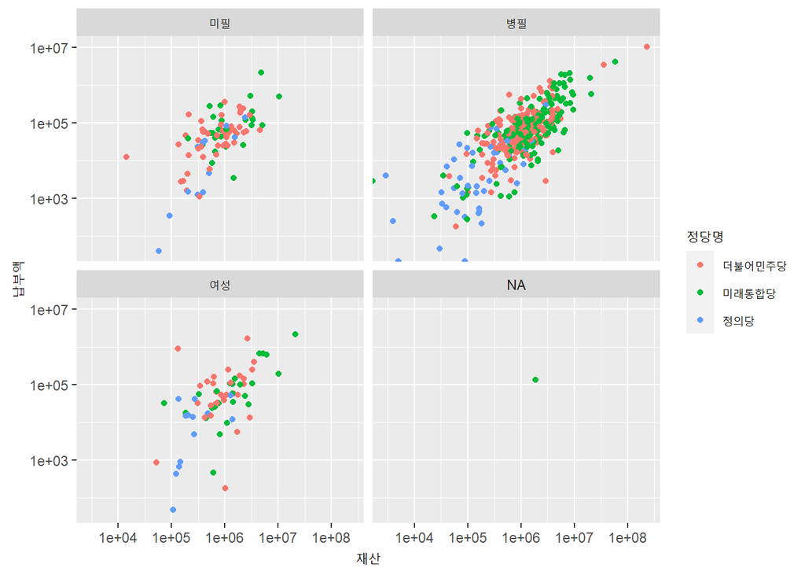

```r
candidate_df %>%
  filter(정당명 %in% c("더불어민주당", "미래통합당", "정의당")) %>%
  ggplot(aes(x=재산, 납부액, color=정당명)) +
    geom_point() +
    scale_x_log10() +
    scale_y_log10() +
    facet_wrap(~병역)
```

## 3.2 연령과 재산

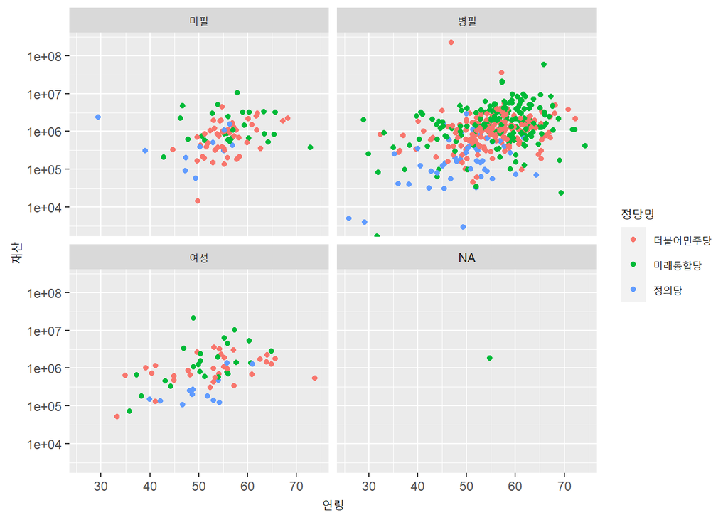

```r
candidate_df %>%
  filter(정당명 %in% c("더불어민주당", "미래통합당", "정의당")) %>%
  ggplot(aes(x=연령, 재산, color=정당명)) +
    geom_jitter() +
    scale_y_log10() +
    facet_wrap(~병역)
```

## 3.3 전과와 입후보횟수

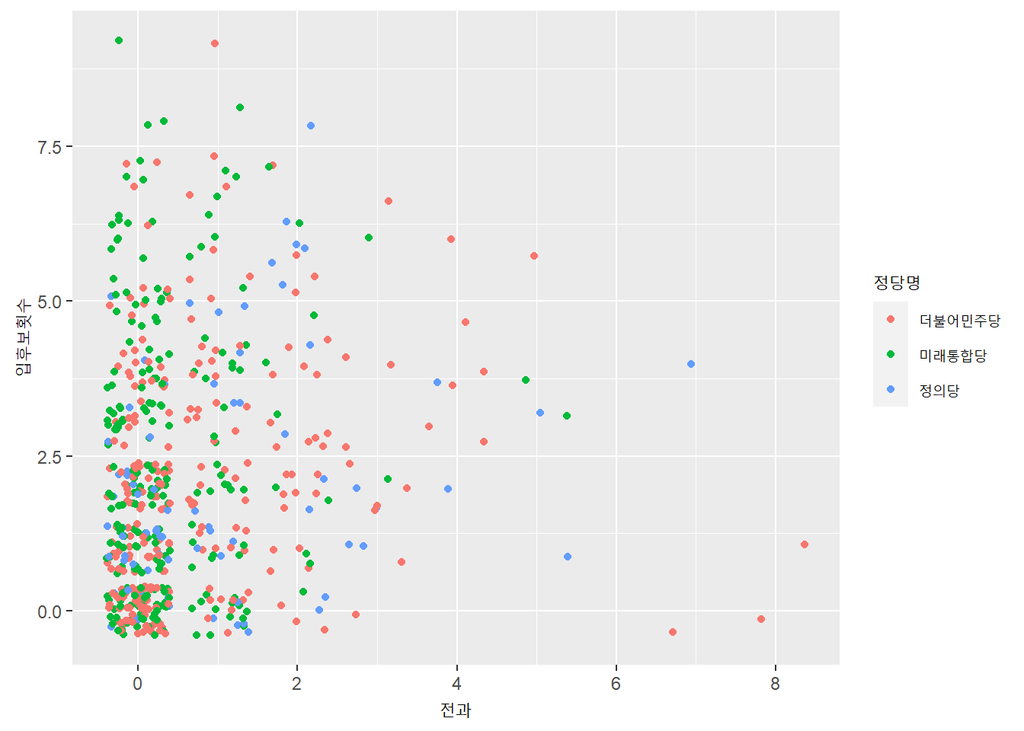

```r
candidate_df %>%
  filter(정당명 %in% c("더불어민주당", "미래통합당", "정의당")) %>%
  ggplot(aes(x=전과, 입후보횟수, color=정당명)) +
    geom_jitter()
```

# 4 지리정보 매칭

## 4.1 정당별 선거구 공천

총 253개 선거구 중에서 미공천된 주요 정당별 미공천된 곳이 얼마인지 확인해보자.

```r
candidate_253_df <- read_rds("data/candidate_253_df.rds")

party_precinct_df <- candidate_253_df %>%
  filter(정당명 %in% c("더불어민주당", "미래통합당", "정의당", "민생당")) %>%
  count(정당명, 시도명, 선거구명) %>%
  spread(정당명, n, fill=0)

party_precinct_df %>%
  gather(정당, 후보자, -시도명, -선거구명) %>%
  group_by(정당) %>%
  summarise(후보자수 = sum(후보자)) %>%
  mutate(미공천 = 253 - 후보자수,
         공천율 = round(후보자수/253 *100,1)) %>%
  knitr::kable()
```

| 정당 | 후보자수 | 미공천 | 공천율 |
| --- | --- | --- | --- |
| 더불어민주당 | 253 | 0 | 100.0 |
| 미래통합당 | 237 | 16 | 93.7 |
| 민생당 | 58 | 195 | 22.9 |
| 정의당 | 77 | 176 | 30.4 |

## 4.2 정당 공천 시각화

```r
## 선거구 253 지도
library(sf)

precinct_sf <- st_read("data/shapefile/2020_21_elec_253_simple.json") %>%
  separate(SGG_2, into=c("시도명", "선거구명"), remove=FALSE) %>%
  rmapshaper::ms_simplify(keep=0.1)
```

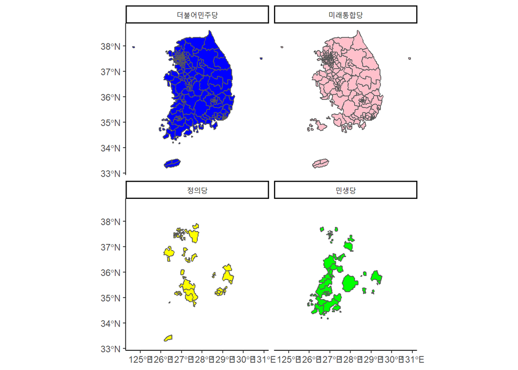

```r
precinct_sf <- precinct_sf %>%
  left_join(candidate_253_df) %>%
  filter(정당명 %in% c("더불어민주당", "미래통합당", "정의당", "민생당")) %>%
  mutate(정당명 = factor(정당명, levels=c("더불어민주당", "미래통합당", "정의당", "민생당")))

precinct_sf %>%
  ggplot(aes(fill=정당명)) +
    geom_sf(aes(fill = 정당명)) +
    scale_fill_manual(values=c("blue", "pink", "yellow", "green"))  +
    facet_wrap(~정당명, scales="fixed") +
    theme_classic() +
    theme(legend.position = "none")
```